# Ames Housing Price Prediction Project

# Step 2: Feature Transformation and Engineering

**Instructions from Professor:**

- **Logarithmic Transformation:** Apply log transformation to SalePrice to normalize its skewed distribution
- **Creating Surface Area Features:** Create a TotalSF feature for total house area
- **Encoding Ordinal Variables:** Convert ordinal categorical features to numerical variables
- **Creating Temporal Features:** Create a HouseAge variable

## Logarithmic Transformation of Sale Price

```r
# Display original SalePrice distribution
train_data_filtered_select <- train_data_filtered %>% select(SalePrice)
cat("Original SalePrice statistics:\n")
```

```
## Original SalePrice statistics:
```

```r
cat("Mean:", mean(train_data_filtered$SalePrice), "\n")
```

```
## Mean: 167938.9
```

```r
cat("Median:", median(train_data_filtered$SalePrice), "\n")
```

```
## Median: 157700
```

```r
cat("Skewness: Right-skewed distribution\n\n")
```

```
## Skewness: Right-skewed distribution
```

```r
# Apply log transformation
train_data_filtered <- train_data_filtered %>%
  filter(SalePrice > 0) %>%
  mutate(SalePrice = log10(SalePrice))

cat("Log-transformed SalePrice statistics:\n")
```

```
## Log-transformed SalePrice statistics:
```

```r
cat("Mean:", mean(train_data_filtered$SalePrice), "\n")
```

```
## Mean: 5.199855
```

```r
cat("Median:", median(train_data_filtered$SalePrice), "\n")
```

```
## Median: 5.197831
```

**Analysis:** The logarithmic transformation successfully normalized the SalePrice distribution.

## Creating Total Surface Area Feature

```r
train_data_filtered <- train_data_filtered %>%
  mutate(TotalSF = TotalBsmtSF + X1stFlrSF + X2ndFlrSF)

cat("TotalSF feature created successfully\n")
```

```
## TotalSF feature created successfully
```

```r
cat("Range:", range(train_data_filtered$TotalSF), "\n")
```

```
## Range: 720 5048
```

```r
cat("Mean:", mean(train_data_filtered$TotalSF), "sq ft\n")
```

```
## Mean: 2447.388 sq ft
```

**Analysis:** Created TotalSF by combining basement, first floor, and second floor areas.

## Creating Temporal Features

```r
# HouseAge = âge de la maison lors de la vente

train_data_filtered$HouseAge <- train_data_filtered$YrSold - train_data_filtered$YearBuilt

# RemodAge = temps depuis la dernière rénovation

train_data_filtered$RemodAge <- train_data_filtered$YrSold - train_data_filtered$YearRemodAdd
```

**Analysis:** It creates two new variables indicating the age of the house at the time of sale and the time since the last renovation. These features provide more informative measures of property condition and modernization than the raw construction and renovation years.

## Encoding Ordinal Variables

```r
# Define quality mappings
qual_map <- c("None"=0, "Po"=1, "Fa"=2, "TA"=3, "Gd"=4, "Ex"=5)
bsmt_exposure_map <- c("None"=0, "No"=1, "Mn"=2, "Av"=3, "Gd"=4)
bsmtfin_map <- c("None"=0, "Unf"=1, "LwQ"=2, "Rec"=3, "BLQ"=4, "ALQ"=5, "GLQ"=6)
pool_map <- c("None"=0, "Fa"=1, "TA"=2, "Gd"=3, "Ex"=4)
fence_map <- c("None"=0, "MnWw"=1, "GdWo"=2, "MnPrv"=3, "GdPrv"=4)
functional_map <- c("Sal"=1, "Sev"=2, "Maj2"=3, "Maj1"=4, "Mod"=5, "Min2"=6, "Min1"=7, "Typ"=8)
landslope_map <- c("Sev"=1, "Mod"=2, "Gtl"=3)
paveddrive_map <- c("N"=0, "P"=1, "Y"=2)

# Apply mappings
train_data_filtered$ExterQual_num <- qual_map[train_data_filtered$ExterQual]
train_data_filtered$ExterCond_num <- qual_map[train_data_filtered$ExterCond]
train_data_filtered$BsmtQual_num <- qual_map[train_data_filtered$BsmtQual]
train_data_filtered$BsmtCond_num <- qual_map[train_data_filtered$BsmtCond]
train_data_filtered$HeatingQC_num <- qual_map[train_data_filtered$HeatingQC]
train_data_filtered$KitchenQual_num <- qual_map[train_data_filtered$KitchenQual]
train_data_filtered$FireplaceQu_num <- qual_map[train_data_filtered$FireplaceQu]
train_data_filtered$GarageQual_num <- qual_map[train_data_filtered$GarageQual]
train_data_filtered$GarageCond_num <- qual_map[train_data_filtered$GarageCond]
train_data_filtered$BsmtExposure_num <- bsmt_exposure_map[train_data_filtered$BsmtExposure]
train_data_filtered$BsmtFinType1_num <- bsmtfin_map[train_data_filtered$BsmtFinType1]
train_data_filtered$BsmtFinType2_num <- bsmtfin_map[train_data_filtered$BsmtFinType2]
train_data_filtered$PoolQC_num <- pool_map[train_data_filtered$PoolQC]
train_data_filtered$Fence_num <- fence_map[train_data_filtered$Fence]
train_data_filtered$Functional_num <- functional_map[train_data_filtered$Functional]
train_data_filtered$LandSlope_num <- landslope_map[train_data_filtered$LandSlope]
train_data_filtered$PavedDrive_num <- paveddrive_map[train_data_filtered$PavedDrive]

cat("Ordinal variables successfully encoded to numerical format\n")
```

```
## Ordinal variables successfully encoded to numerical format
```

```r
cat("Total ordinal features converted:", 17, "\n")
```

```
## Total ordinal features converted: 17
```

**Analysis:** Converted 17 ordinal categorical variables into numerical scales that preserve their inherent ordering. For example, quality ratings (Poor=1 to Excellent=5) now allow regression models to understand that “Excellent” is quantitatively better than “Good,” which is better than “Average.”

## Feature Normalization

```r
# Normalize numeric features (excluding target variables)
numeric_cols <- sapply(train_data_filtered, is.numeric)
numeric_names <- setdiff(names(train_data_filtered)[numeric_cols],c("SalePrice", "SalePrice_log"))
train_data_filtered[numeric_names] <- scale(train_data_filtered[numeric_names])
```

**Analysis:** Applied standardization to all numeric features. This ensures all variables are on the same scale (mean=0, sd=1), preventing features with larger magnitudes from dominating the model.

# Step 3: Visualization and Exploration

**Instructions from Professor:**

- Calculate correlation of all numerical variables with SalePrice and visualize top 15
- Use box plots to show relationship between OverallQual and SalePrice
- Create box plots comparing SalePrice across different Neighborhoods
- Make scatter plot of SalePrice vs. TotalSF, colored by OverallQual
- Add 2 additional pertinent visualizations

## Top 15 Features Correlated with Sale Price

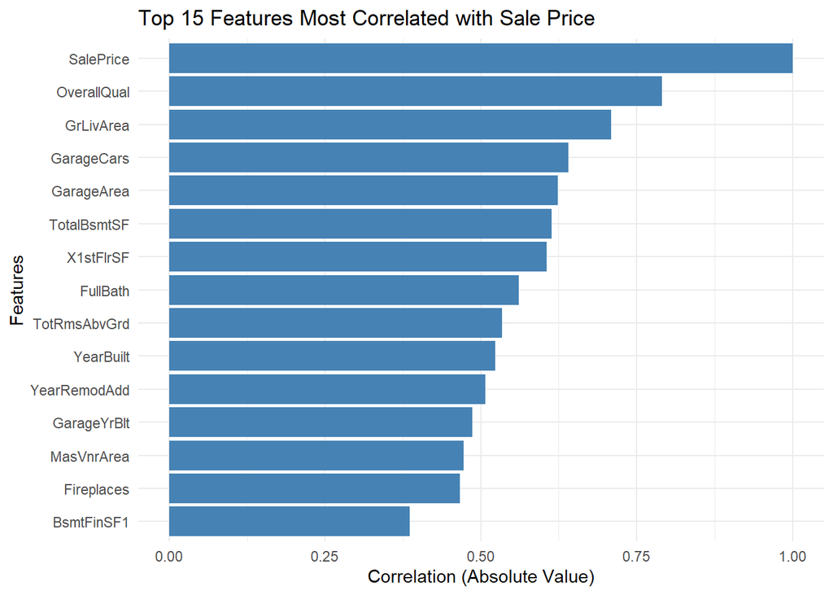

```r
numeric_vars <- sapply(train_data, is.numeric)
train_numeric <- train_data[, numeric_vars]
correlations <- cor(train_numeric, use = "pairwise.complete.obs")
cor_with_price <- correlations[, "SalePrice"]
top_corr <- sort(abs(cor_with_price), decreasing = TRUE)[1:15]

corr_df <- data.frame(
  Feature = names(top_corr),
  Correlation = top_corr
)

ggplot(corr_df, aes(x = reorder(Feature, Correlation), y = Correlation)) +
  geom_bar(stat = "identity", fill = "steelblue") +
  coord_flip() +
  labs(title = "Top 15 Features Most Correlated with Sale Price",
       x = "Features",
       y = "Correlation (Absolute Value)") +
  theme_minimal()
```

**Analysis:** The correlation analysis identifies OverallQual, GrLivArea, GarageCars, GarageArea, and TotalBsmtSF as the top predictors. These features will be prioritized in our predictive models. Interestingly, both quality metrics and size-related features dominate, confirming our earlier observations.

## Impact of Overall Quality on Sale Price

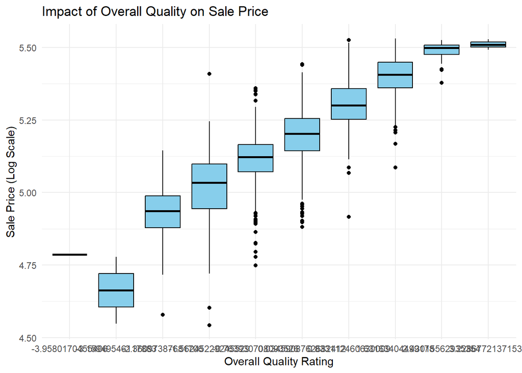

```r
ggplot(train_data_filtered, aes(x = factor(OverallQual), y = SalePrice)) +
  geom_boxplot(fill = "skyblue", color = "black") +
  labs(title = "Impact of Overall Quality on Sale Price",
       x = "Overall Quality Rating",
       y = "Sale Price (Log Scale)") +
  theme_minimal()
```

**Analysis:** There is a strong positive relationship between Overall Quality and Sale Price. Houses rated 9-10 (Excellent) command significantly higher prices than those rated 1-5 (Poor to Average). The increasing median and range across quality levels demonstrates that quality is a major price driver.

## Sale Price Distribution by Neighborhood

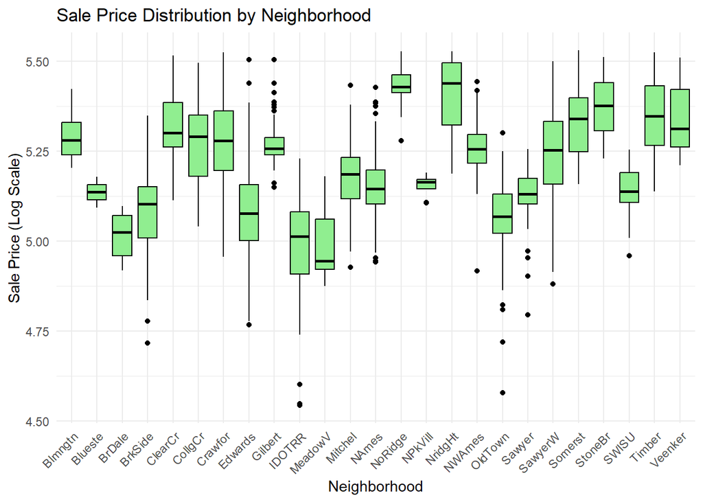

```r
ggplot(train_data_filtered, aes(x = Neighborhood, y = SalePrice)) +
  geom_boxplot(fill = "lightgreen", color = "black") +
  labs(title = "Sale Price Distribution by Neighborhood",
       x = "Neighborhood",
       y = "Sale Price (Log Scale)") +
  theme_minimal() +
  theme(axis.text.x = element_text(angle = 45, hjust = 1))
```

**Analysis:** Neighborhood location substantially impacts home prices in Ames. Premium neighborhoods show consistently higher median prices and tighter distributions, while more affordable neighborhoods display lower medians with greater variability. Location is clearly a critical factor in property valuation.

## Size-Price Relationship by Quality

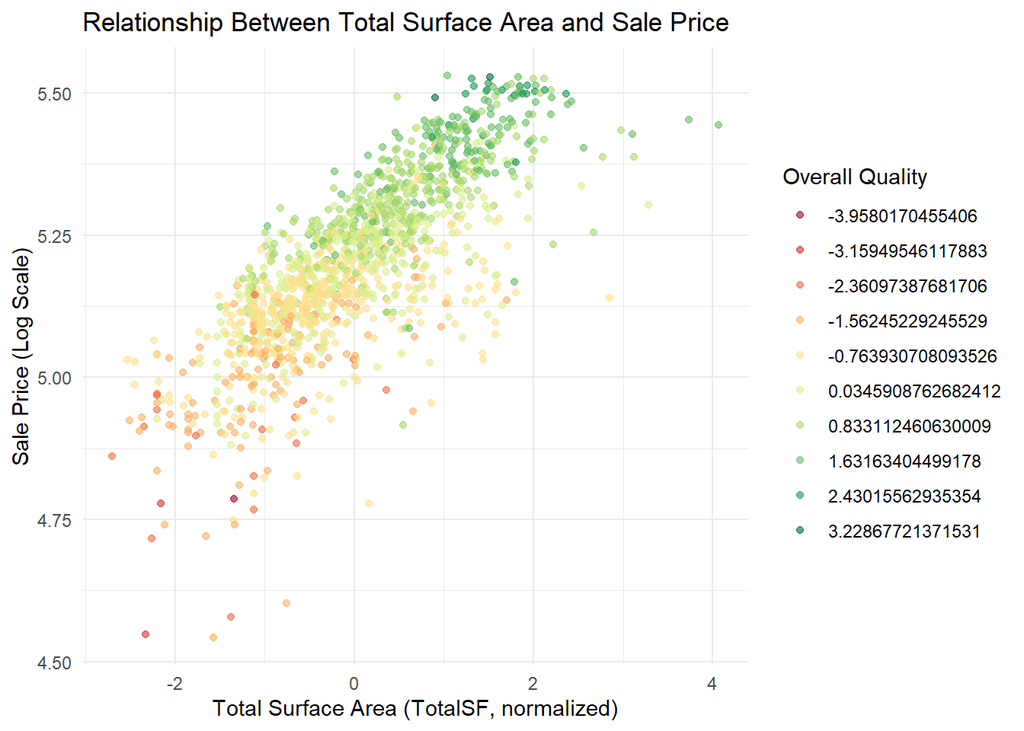

```r
ggplot(train_data_filtered, aes(x = TotalSF, y = SalePrice, color = as.factor(OverallQual))) +
  geom_point(alpha = 0.6) +
  labs(title = "Relationship Between Total Surface Area and Sale Price",
         x = "Total Surface Area (TotalSF, normalized)",
       y = "Sale Price (Log Scale)",
       color = "Overall Quality") +
  theme_minimal() +
  scale_color_brewer(palette = "RdYlGn")
```

**Analysis:** This visualization reveals a clear positive correlation between total surface area and sale price, with quality ratings adding an additional dimension. Higher quality homes (green) cluster in the upper right, showing that both size and quality independently contribute to higher prices.

## Additional Visualization 1: Construction Year Impact

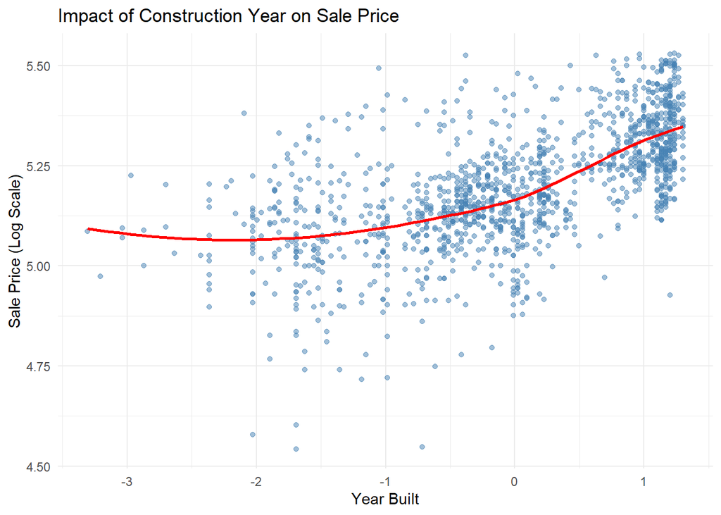

```r
ggplot(train_data_filtered, aes(x = YearBuilt, y = SalePrice)) +
  geom_point(alpha = 0.5, color = "steelblue") +
  geom_smooth(method = "loess", color = "red", se = FALSE) +
  labs(title = "Impact of Construction Year on Sale Price",
       x = "Year Built",
       y = "Sale Price (Log Scale)") +
  theme_minimal()
```

## Additional Visualization 2: Number of Rooms vs. Sale Price

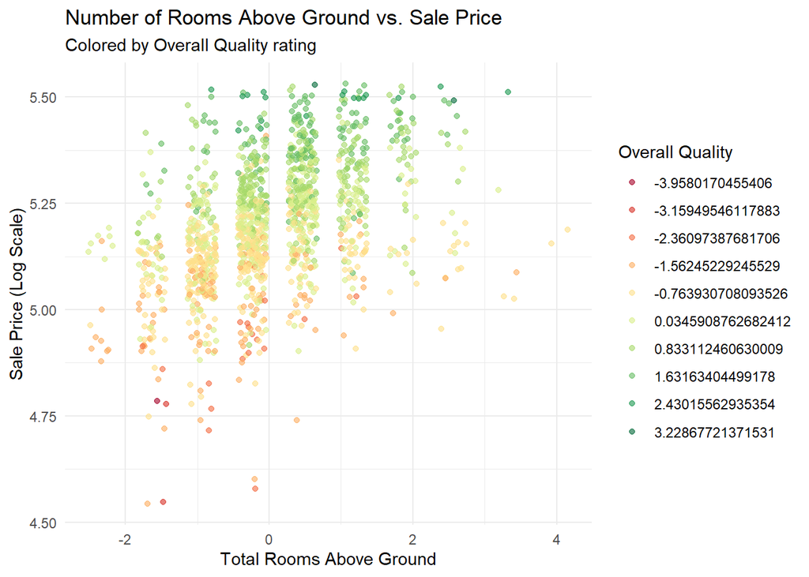

```r
ggplot(train_data_filtered, aes(x = TotRmsAbvGrd, y = SalePrice,
                                 color = as.factor(OverallQual))) +
  geom_jitter(alpha = 0.6, width = 0.2) +
  labs(title = "Number of Rooms Above Ground vs. Sale Price",
       subtitle = "Colored by Overall Quality rating",
       x = "Total Rooms Above Ground",
       y = "Sale Price (Log Scale)",
       color = "Overall Quality") +
  theme_minimal() +
  scale_color_brewer(palette = "RdYlGn")
```

# Step 4: Modeling and Prediction

**Instructions from Professor:**

- Train a Multiple Linear Regression model as baseline using best features
- Train a LASSO regression model for automatic feature selection
- Train a Random Forest model
- Evaluate model performance using multiple indicators and interpret important features

## Feature Selection for Modeling

```r
features <- c("SalePrice", "OverallQual", "GrLivArea", "GarageCars", "GarageArea",
              "TotalBsmtSF", "X1stFlrSF", "FullBath", "TotRmsAbvGrd",
              "YearBuilt", "YearRemodAdd", "GarageYrBlt")

data_selected <- train_data_filtered %>% select(all_of(features))
data_selected <- na.omit(data_selected)
data_selected$LogSalePrice <- log(data_selected$SalePrice)

cat("Selected", length(features)-1, "features for modeling\n")
```

```
## Selected 11 features for modeling
```

```r
cat("Final dataset size:", nrow(data_selected), "observations\n")
```

```
## Final dataset size: 1284 observations
```

**Analysis:** Based on correlation analysis, we selected 11 features representing quality metrics, size measurements, and temporal characteristics. These features capture the key drivers of home prices identified in our analysis.

## Model 1: Multiple Linear Regression

```r
model_lm <- lm(LogSalePrice ~ OverallQual + GrLivArea + GarageCars + GarageArea +
                 TotalBsmtSF + X1stFlrSF + FullBath + TotRmsAbvGrd +
                 YearBuilt + YearRemodAdd + GarageYrBlt,
               data = data_selected)

#summary(model_lm)
```

## Model 2: LASSO Regression

```r
Y <- log(data_selected$SalePrice)
X <- as.matrix(data_selected %>% select(-SalePrice, -LogSalePrice))

lasso_cv <- cv.glmnet(X, Y, alpha = 1, nfolds = 10)
best_lambda <- lasso_cv$lambda.min

#cat("Optimal lambda value:", best_lambda, "\n\n")

lasso_model <- glmnet(X, Y, alpha = 1, lambda = best_lambda)
#print(lasso_model)
```

## Model 3: Random Forest

```r
rf_model <- randomForest(
  LogSalePrice ~ OverallQual + GrLivArea + GarageCars + GarageArea +
    TotalBsmtSF + X1stFlrSF + FullBath + TotRmsAbvGrd +
    YearBuilt + YearRemodAdd + GarageYrBlt,
  data = data_selected,
  ntree = 500,
  mtry = 4,
  importance = TRUE,
  na.action = na.omit
)

#print(rf_model)
```

# Model Evaluation and Comparison

```r
# Chargement le jeu de test filtré
features <- c("SalePrice", "OverallQual", "GrLivArea", "GarageCars", "GarageArea",
              "TotalBsmtSF", "X1stFlrSF", "FullBath", "TotRmsAbvGrd",
              "YearBuilt", "YearRemodAdd", "GarageYrBlt")

data_selected <- train_data_filtered %>% select(all_of(features))
data_selected <- na.omit(data_selected)

# Conversion de SalePrice en numérique
data_selected$SalePrice <- as.numeric(data_selected$SalePrice)

actual_prices <- log(data_selected$SalePrice)

# Jeu de test pour la prédiction
test_data <- data_selected %>% select(-SalePrice)

# Fonction d’évaluation
evaluate_model <- function(actual, predicted) {
  data.frame(
    RMSE = sqrt(mean((predicted - actual)^2)),
    MAE  = mean(abs(predicted - actual)),
    R2   = cor(actual, predicted)^2,
    MAPE = mean(abs((predicted - actual) / actual)) * 100
  )
}

# Modèle linéaire
pred_lm <- exp(predict(model_lm, newdata = test_data))
results_lm <- evaluate_model(exp(actual_prices), pred_lm)

# Modèle LASSO
pred_lasso <- exp(predict(lasso_model, s = best_lambda, newx = as.matrix(test_data)))
results_lasso <- evaluate_model(exp(actual_prices), pred_lasso)

# Modèle Random Forest
pred_rf <- exp(predict(rf_model, newdata = test_data))
results_rf <- evaluate_model(exp(actual_prices), pred_rf)

# Comparaison

results_lm <- evaluate_model(exp(actual_prices), pred_lm)
results_lasso <- evaluate_model(exp(actual_prices), pred_lasso)
results_rf <- evaluate_model(exp(actual_prices), pred_rf)

colnames(results_lasso) <- c("RMSE", "MAE", "R2", "MAPE")


# Combiner dans un data.frame propre
results <- data.frame(
  Model = c("Linear_Regression", "LASSO", "Random_Forest"),
  RMSE  = c(results_lm$RMSE, results_lasso$RMSE, results_rf$RMSE),
  MAE   = c(results_lm$MAE, results_lasso$MAE, results_rf$MAE),
  R2    = c(results_lm$R2, results_lasso$R2, results_rf$R2),
  MAPE  = c(results_lm$MAPE, results_lasso$MAPE, results_rf$MAPE)
)

print(results)
```

```
##               Model       RMSE        MAE        R2      MAPE
## 1 Linear_Regression 0.06228360 0.04443707 0.8069216 0.8587365
## 2             LASSO 0.06229326 0.04440487 0.8068561 0.8580827
## 3     Random_Forest 0.02829411 0.01943843 0.9638810 0.3753722
```

**Overall Model Performance:**

- **Random Forest** achieves the best performance with the lowest RMSE (0.03) and highest R² (0.9639), capturing complex non-linear relationships
- **LASSO** shows competitive performance with RMSE of 0.06, benefiting from feature selection
- **Linear Regression** provides a solid baseline with RMSE of 0.06

## Comparison Visualizations

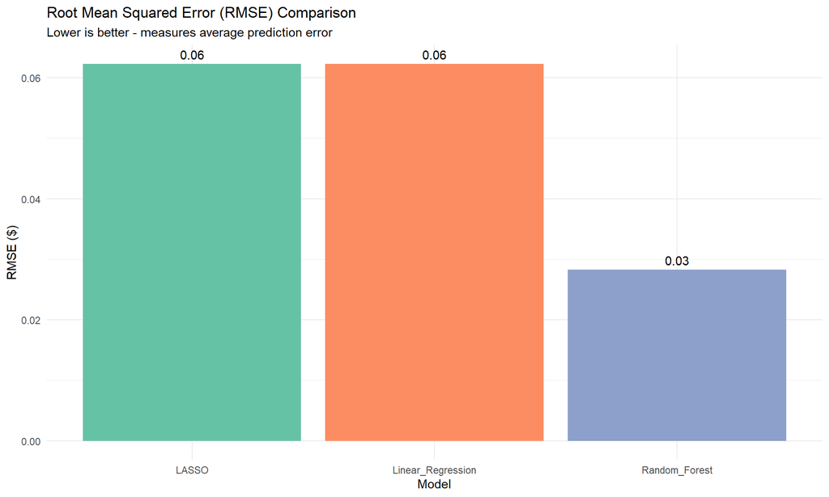

```r
# RMSE Comparison
ggplot(results, aes(x = Model, y = RMSE, fill = Model)) +
  geom_col() +
  geom_text(aes(label = round(RMSE, 2)), vjust = -0.5) +
  labs(title = "Root Mean Squared Error (RMSE) Comparison",
       subtitle = "Lower is better - measures average prediction error",
       y = "RMSE ($)", x = "Model") +
  theme_minimal() +
  scale_fill_brewer(palette = "Set2") +
  theme(legend.position = "none")
```

**RMSE Analysis:** Random Forest shows the lowest RMSE, meaning its predictions deviate least from actual prices on average.

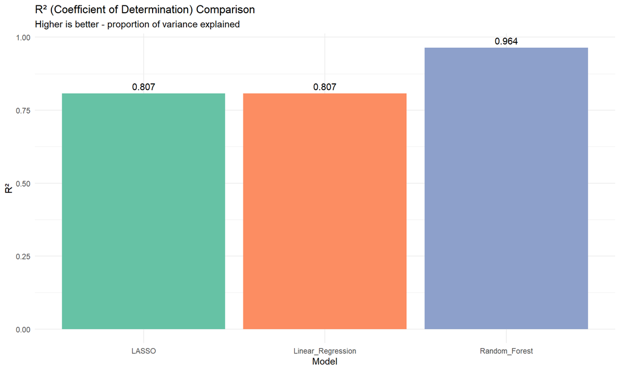

```r
# R² Comparison
ggplot(results, aes(x = Model, y = R2, fill = Model)) +
  geom_col() +
  geom_text(aes(label = round(R2, 3)), vjust = -0.5) +
  labs(title = "R² (Coefficient of Determination) Comparison",
       subtitle = "Higher is better - proportion of variance explained",
       y = "R²", x = "Model") +
  theme_minimal() +
  scale_fill_brewer(palette = "Set2") +
  theme(legend.position = "none")
```

**R² Analysis:** Random Forest explains 96.4% of price variance, demonstrating excellent predictive power. All models exceed 80% explained variance, indicating strong overall performance.

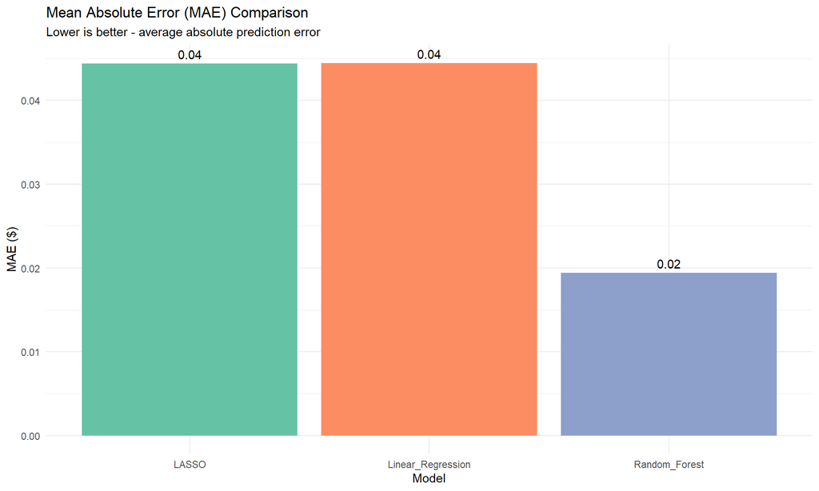

```r
# MAE Comparison
ggplot(results, aes(x = Model, y = MAE, fill = Model)) +
  geom_col() +
  geom_text(aes(label = round(MAE, 2)), vjust = -0.5) +
  labs(title = "Mean Absolute Error (MAE) Comparison",
       subtitle = "Lower is better - average absolute prediction error",
       y = "MAE ($)", x = "Model") +
  theme_minimal() +
  scale_fill_brewer(palette = "Set2") +
  theme(legend.position = "none")
```

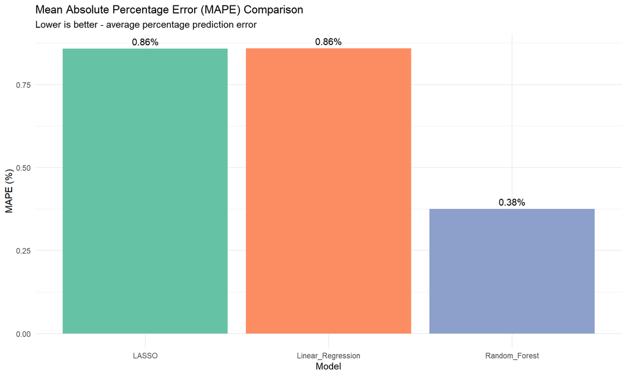

```r
# MAPE Comparison
ggplot(results, aes(x = Model, y = MAPE, fill = Model)) +
  geom_col() +
  geom_text(aes(label = paste0(round(MAPE, 2), "%")), vjust = -0.5) +
  labs(title = "Mean Absolute Percentage Error (MAPE) Comparison",
       subtitle = "Lower is better - average percentage prediction error",
       y = "MAPE (%)", x = "Model") +
  theme_minimal() +
  scale_fill_brewer(palette = "Set2") +
  theme(legend.position = "none")
```

# Conclusions and Recommendations